# Part II - (Ford GoBike System Data)

## by (Khadijah Alsaggaf)

## Investigation Overview

> The overal goals of this presentation are show the foloowing: - Duration of the trips, - Is the duration of the trip affected by the user age?, - Is the user type affect in the trips duration?

## Dataset Overview

> Ford GoBike System Data: This data set includes information about individual rides made in a bike-sharing system covering the greater San Francisco Bay area for 2019-02. The dataset contains of 183412 rows about trips and 16 features with a different types: features describe the trip information (duration, start_time, end_time) features describe the location of the trip(start_station_id, start_station_name, start_station_latitude start_station_longitude end_station_id, end_station_name, end_station_latitude, end_station_longitude) features about user information (user_type, member_birth_year, member_gender)

## How long the average of the trip?

The trip duration is take a large range from 1 min to 23 hour, so to studying the distribution of the trip. First visualize the duration for 60 minutes only, and then distribute the durations by hours.

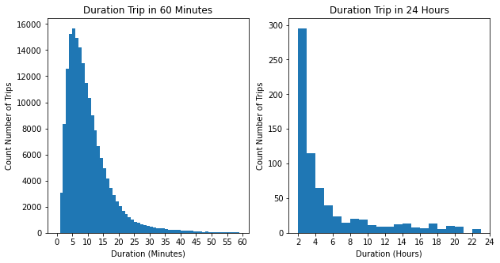

## Is the duration of the trip affected by the user age and gender??

- First, showing the distribution of the trip duration by gender.
- Then, showing the distribution of the trip duration by ages.
- Finally show the realtion between duration, age and gender.

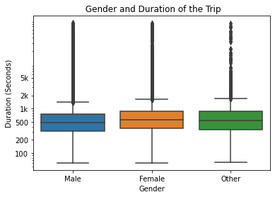

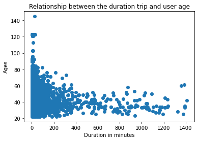

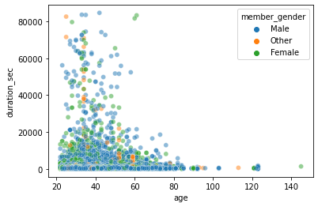

## Is the user type affect in the trips duration?

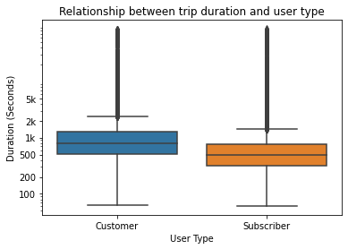